# Colorado Flood Assignment

21 March, 2019

## The Big One

In early September 2013, a slow moving cold front moved through Colorado intersecting with a warm, humid front. The clash between the cold and warm fronts yielded heavy rain and devastating flooding across the Front Range in Colorado. The storm that caused the 2013 Colorado flooding was kept in a confined area over the Eastern Range of the Rocky Mountains in Colorado by these water vapor systems.

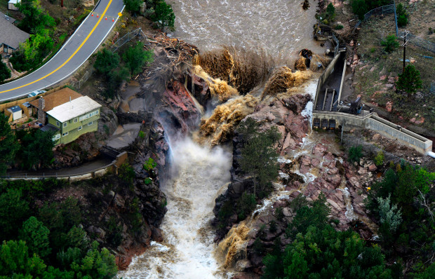

Boulder County was worst hit, with 9.08 inches (231 mm) recorded September 12 and up to 17 inches (430 mm) of rain recorded by September 15, which is comparable to Boulder County’s average annual precipitation (525 mm). The National Weather Service stated that the probability for the entire rainfall event was as low as 1/1000 (0.1%) in places. The flood waters spread across a range of almost 200 miles, affecting 17 counties, with more than 11,000 people evacuated.

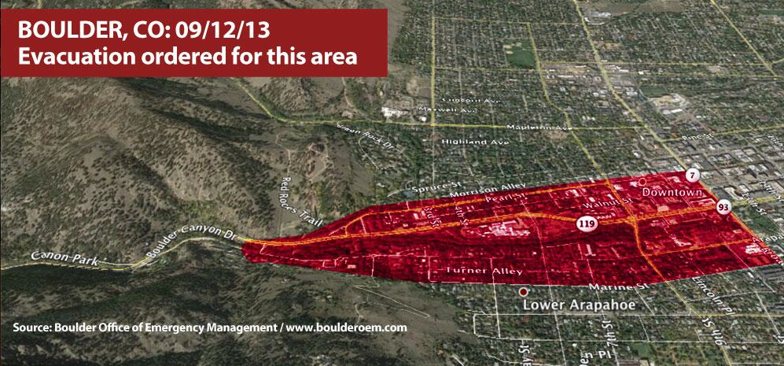

## Assignment

You are tasked with investigating the factors that led to this 1 in 1000 year flood. There are several data sets to explore, including; precipitation, stream gauge outflow and drought data for the watershed where the flood occurred. You will need to format and manipulate the data to find your answers.

This assignment is different from previous mystery data exercises because you will have to examine multiple data sets to evaluate what led to the flood. Please turn in a reproducible document in which you have thoroughly investigated this ecological disturbance. This assignment is very applied, aimed at helping you digest and interpret data with a more goal oriented focus (less exploratory).

**Here are the specifics for the assignment but feel free to take it farther if you see fit:**

1) Visualize the complete precipitation data from NOAA for the Colorado Basin by month. Are there any strong annual or seasonal patterns? Do any other events over the last 65 years resemble the September 2013 event?

2) Separately, visualize and interpret patterns in precipitation leading up to the 2013 flood

3) Investigate the severity (or lack thereof) of drought in Colorado before the 2013 floods with the Palmer Drought Severioty Index (PDSI).

**hint: Were the months leading up to the September 2013 floods or drought? What was the historical legacy of “wet” and “dry” years in the area**

4) Visualize any patterns you choose to discuss regarding PDSI

5) The climate_co data set includes several other measures of precipitation, drought and temperature. Investigate these variables and visualize any interesting patterns regarding the Boulder, CO floods. Add 1 additional figure and discuss it’s relevance to the floods and other variables you discuss.

6) The heavy precipitation (rain) that occurred in September 2013 caused much damage during the 2013 flood by, among other things, increasing stream discharge (flow). Visualize and discuss the temporal patterns of stream discharge around the flooding event.

**Data Formatting:**

1) Make sure you dates and times are in the proper format  
2) Check all data sets for Nodata values (i.e. -999.99) and set to ‘NA’  
3) Confirm you are using data from the correct watershed for Boulder area? (CO-04 Platte River Drainage)  
4) Inspect variable names with metadata (rename if you have too).

Below, I have included background material for some of the data sets to help you write your report

## Palmer Drought Severity Index (PDSI)

PDSI is a hydrological drought index used to assess long-term moisture supply. PDSI is a monthly value (index) that indicates the severity of a wet or dry spell. This index is based on the principles of a balance between moisture supply and demand. The index generally ranges from - 6 to +6, with negative values denoting dry spells, and positive values indicating wet spells. Values exceeding -2 indicate moderate drought and greater than -4 indicate extreme drought. Similar adjectives are attached to positive values of wet spells.

There is a connection between the dry soils during a drought and the potential for flooding. In a severe drought the top layers of the soil dry out. Organic matter, spongy and absorbent in moist topsoil, may desiccate and be transported by the winds to other areas. Some soil types, like clay, can dry to a near-impermeable brick causing water to flow across the top instead of sinking into the soils.

## Precipitation

Boulder, CO lays on the eastern edge of the Rocky Mountains where they meet the high plains. The average annual precipitation is near 20 in. However, the precipitation comes in many forms – winter snow, intense summer thunderstorms, and intermittent storms throughout the year.

Precipitation can be measured by different types of gauges; some must be manually read and emptied, others automatically record the amount of precipitation. If the precipitation is in a frozen form (snow, hail, freezing rain) the contents of the gauge must be melted to get the water equivalency for measurement. Rainfall is generally reported as the total amount of rain (millimeters, centimeters, or inches) over a given per period of time.

## Stream Discharge

The USGS has a distributed network of aquatic sensors located in streams across the United States, which monitors variables that are important to stream morphology and health. One of the metrics that this sensor network monitors is Stream Discharge, a metric which quantifies the volume of water moving down a stream (cubic feet per second or gallons per day). In general, river discharge is computed by multiplying the area of water in a channel cross section by the average velocity of the water in that cross section.Discharge is an ideal metric to quantify flow, which increases significantly during a flood event.

Most USGS stream gauges operate by measuring the elevation of the water in the river or stream and then converting the water elevation (called ‘stage’) to a stream flow (‘discharge’) by using a curve that relates the elevation to a set of actual discharge measurements.

**Here, we want data collected by USGS stream gauge 06730200 located on Boulder Creek at North 75th St. This gauge is one of the few the was able to continuously collect data throughout the 2013 Boulder floods.**

## Human health & impacts

If interested, you can look at the Boulder city resources on human impacts and link it into the data story they are telling. Just click on the link below:

https://bouldercolorado.gov/flood/flood-maps